# 23c0ec9e-ea40-4235-8add-4b54b7d5a3fe

Привет, Наталья!👋 Меня зовут Эльвира Нургалиева, я буду ревьюером твоего проекта. Предлагаю общаться на «ты», но если это не удобно - дай мне знать, и мы перейдем на «вы». Ты можешь найти мои комментарии, обозначенные зеленым, желтым и красным цветами, например:

## Комментарий ревьюера 😊

Такими комментариями я буду помечать отлично проделаную работу😉

## Комментарий ревьюера 🤓

В таких комментариях я постараюсь подсказать тебе более элегантное или легкое решение, некоторые хитрости и фишки. Части проекта, помеченные такими комментариями, можно не исправлять, но рекомендую обратить на них внимание.

## Комментарий ревьюера 🤔

В случае, когда решение на отдельном шаге требует существенной переработки и внесения правок. Если ты видишь такой комментарий, значит здесть есть недочет, который следует исправить.

Ты также можешь реагировать на мои комментарии своими, выделяя их цветами и наиболее понравившимся тебе способом оформления, но явно отличающимся от моих комментариев. Это нужно, чтобы не создавалась путаница🙃

**Комментарий студента:** Например, вот так.

Чтобы сделать подобный блок, кликни здесь дважды и скопируй всю предыдущую строку ;)

# Сборный проект

# Описание проекта

## Задача:

Выявить определяющие успешность игры закономерности. Это позволит сделать ставку на потенциально популярный продукт и спланировать рекламные кампании.

## Инструкция по выполнению проекта:

- Шаг 1. Откройте файл с данными и изучите общую информацию
- Шаг 2. Подготовьте данные
- Шаг 3. Проведите исследовательский анализ данных
- Шаг 4. Составьте портрет пользователя каждого региона
- Шаг 5. Проверьте гипотезы
- Шаг 6. Напишите общий вывод

## Описание данных

- Name — название игры
- Platform — платформа
- Year_of_Release — год выпуска
- Genre — жанр игры
- NA_sales — продажи в Северной Америке (миллионы проданных копий)
- EU_sales — продажи в Европе (миллионы проданных копий)
- JP_sales — продажи в Японии (миллионы проданных копий)
- Other_sales — продажи в других странах (миллионы проданных копий)
- Critic_Score — оценка критиков (максимум 100)
- User_Score — оценка пользователей (максимум 10)
- Rating — рейтинг от организации ESRB (англ. Entertainment Software Rating Board). Эта ассоциация определяет рейтинг компьютерных игр и присваивает им подходящую возрастную категорию.

## Комментарий ревьюера 🤓

Введение можно улучшить, если в описании проекта мы добавим основные задачи, особенно с позиции бизнес задачи, которая решается, описание данных и краткий план работы, основные этапы, которые мы должны выполнить.

**Комментарий студента:** вроде, исправила). Или нужно что-то еще?)

## Комментарий ревьюера 😊 v_2

Все отлично)

## Шаг 1. Откройте файл с данными и изучите общую информацию

```python
import pandas as pd
import numpy as np
import seaborn as sns
import matplotlib.pyplot as plt

from scipy import stats as st
```

## Комментарий ревьюера 😊

Молодец, что загружаешь все библиотеки в начале проекта. Так сложней случайно удалить ячейку с загрузкой нужной библиотеки и сделать код не работающим. А получатель отчета сразу поймет, какие библиотеки ты используешь и какие ему нужно установить для запуска проекта. Все ли библиотеки используются? Лучше оставить только используемые в данном проекте)

```python
try:
    data = pd.read_csv('/datasets/games.csv', sep=',')
except:
    data = pd.read_csv('./datasets/games.csv', sep=',')
```

## Шаг 2. Подготовьте данные

- Замените названия столбцов (приведите к нижнему регистру);
- Преобразуйте данные в нужные типы. Опишите, в каких столбцах заменили тип данных и почему;
- Обработайте пропуски при необходимости:
- Объясните, почему заполнили пропуски определённым образом или почему не стали это делать;
- Опишите причины, которые могли привести к пропускам;
- Обратите внимание на аббревиатуру 'tbd' в столбце с оценкой пользователей. Отдельно разберите это значение и опишите, как его обработать;
- Посчитайте суммарные продажи во всех регионах и запишите их в отдельный столбец.

```python
# check

data.info()
```

```
<class 'pandas.core.frame.DataFrame'>
RangeIndex: 16715 entries, 0 to 16714
Data columns (total 11 columns):
 #   Column           Non-Null Count  Dtype
---  ------           --------------  -----
 0   Name             16713 non-null  object
 1   Platform         16715 non-null  object
 2   Year_of_Release  16446 non-null  float64
 3   Genre            16713 non-null  object
 4   NA_sales         16715 non-null  float64
 5   EU_sales         16715 non-null  float64
 6   JP_sales         16715 non-null  float64
 7   Other_sales      16715 non-null  float64
 8   Critic_Score     8137 non-null   float64
 9   User_Score       10014 non-null  object
 10  Rating           9949 non-null   object
dtypes: float64(6), object(5)
memory usage: 1.4+ MB
```

```python
# Замените названия столбцов (приведите к нижнему регистру)

data.columns = map(str.lower, data.columns)
```

```python
# Поиск пропусков

def get_pass_data_frame(df):
    try:
        return (
            df.isnull().sum().sort_values()
            .to_frame()
            .rename(columns = {0: 'space'})
            .query('space > 0')
        )

    except:
        print('пропусков не осталось :) ')
```

```python
pass_data_frame = get_pass_data_frame(data)
```

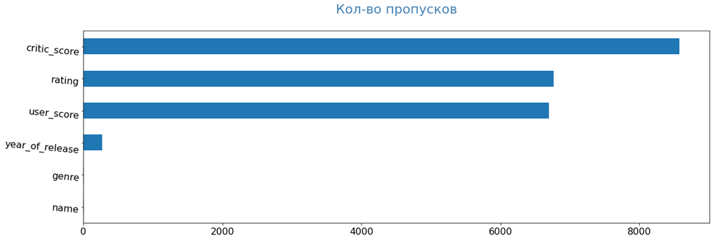

```python
pass_data_frame.plot(
    kind='barh', figsize=(19, 6), rot=-5, legend=False, fontsize=16).set_title(
    'Кол-во пропусков' + "\n", fontsize=22, color='SteelBlue');
```

Вывод по графику:

На графике видно, что самое большое количество пропусков в столбцах critic_score, rating, user_score Всего данных 16713, в столбцах, показанных на графике 30-50% пропусков

## Комментарий ревьюера 🤔

Давай добавим комментарий к нашему замечательному графику по пропускам)

## Комментарий ревьюера 😊 v_2

👍

```python
# Преобразуйте данные в нужные типы. Обработайте пропуски при необходимости

data = data.dropna(subset=['year_of_release', 'name', 'genre'])
data['year_of_release'] = data['year_of_release'].astype('int64')

data['critic_score'] = data['critic_score'].astype('Int64')

data.loc[data['user_score'] == 'tbd', 'user_score'] = np.nan
data['user_score'] = data['user_score'].astype('float64')

data['rating'] = data['rating'].fillna(0)
```

```python
# check

data.info()
```

```
<class 'pandas.core.frame.DataFrame'>
Int64Index: 16444 entries, 0 to 16714
Data columns (total 11 columns):
 #   Column           Non-Null Count  Dtype
---  ------           --------------  -----
 0   name             16444 non-null  object
 1   platform         16444 non-null  object
 2   year_of_release  16444 non-null  int64
 3   genre            16444 non-null  object
 4   na_sales         16444 non-null  float64
 5   eu_sales         16444 non-null  float64
 6   jp_sales         16444 non-null  float64
 7   other_sales      16444 non-null  float64
 8   critic_score     7983 non-null   Int64
 9   user_score       7463 non-null   float64
 10  rating           16444 non-null  object
dtypes: Int64(1), float64(5), int64(1), object(4)
memory usage: 1.5+ MB
```

## Комментарий ревьюера 😊

Типы преобразованы верно, tbd действительно по значению схож с пропуском, так что логичная замена)

```python
# поиск дубликатов

data.drop_duplicates(subset=['name', 'platform'], keep=False)
```

|  | name | platform | year_of_release | genre | na_sales | eu_sales | jp_sales | other_sales | critic_score | user_score | rating |
| --- | --- | --- | --- | --- | --- | --- | --- | --- | --- | --- | --- |
| 0 | Wii Sports | Wii | 2006 | Sports | 41.36 | 28.96 | 3.77 | 8.45 | 76 | 8.0 | E |
| 1 | Super Mario Bros. | NES | 1985 | Platform | 29.08 | 3.58 | 6.81 | 0.77 | <NA> | NaN | 0 |
| 2 | Mario Kart Wii | Wii | 2008 | Racing | 15.68 | 12.76 | 3.79 | 3.29 | 82 | 8.3 | E |
| 3 | Wii Sports Resort | Wii | 2009 | Sports | 15.61 | 10.93 | 3.28 | 2.95 | 80 | 8.0 | E |
| 4 | Pokemon Red/Pokemon Blue | GB | 1996 | Role-Playing | 11.27 | 8.89 | 10.22 | 1.00 | <NA> | NaN | 0 |
| ... | ... | ... | ... | ... | ... | ... | ... | ... | ... | ... | ... |
| 16710 | Samurai Warriors: Sanada Maru | PS3 | 2016 | Action | 0.00 | 0.00 | 0.01 | 0.00 | <NA> | NaN | 0 |
| 16711 | LMA Manager 2007 | X360 | 2006 | Sports | 0.00 | 0.01 | 0.00 | 0.00 | <NA> | NaN | 0 |
| 16712 | Haitaka no Psychedelica | PSV | 2016 | Adventure | 0.00 | 0.00 | 0.01 | 0.00 | <NA> | NaN | 0 |
| 16713 | Spirits & Spells | GBA | 2003 | Platform | 0.01 | 0.00 | 0.00 | 0.00 | <NA> | NaN | 0 |
| 16714 | Winning Post 8 2016 | PSV | 2016 | Simulation | 0.00 | 0.00 | 0.01 | 0.00 | <NA> | NaN | 0 |

16438 rows × 11 columns

## Комментарий ревьюера 🤔 v_2

Дубликаты по названию могли быть вызваны тем, что одна и та же игра выходила на разных платформах, так мы удалили значительную часть данных, что некорректно.

## Комментарий ревьюера 😊 v_3

Верно.

```python
# Посчитайте суммарные продажи во всех регионах и запишите их в отдельный столбец

data['sum_sales'] = data['na_sales'] + data['eu_sales'] + data['jp_sales'] + data['other_sales']
```

```python
# check

data.info()
```

```
<class 'pandas.core.frame.DataFrame'>
Int64Index: 16444 entries, 0 to 16714
Data columns (total 12 columns):
 #   Column           Non-Null Count  Dtype
---  ------           --------------  -----
 0   name             16444 non-null  object
 1   platform         16444 non-null  object
 2   year_of_release  16444 non-null  int64
 3   genre            16444 non-null  object
 4   na_sales         16444 non-null  float64
 5   eu_sales         16444 non-null  float64
 6   jp_sales         16444 non-null  float64
 7   other_sales      16444 non-null  float64
 8   critic_score     7983 non-null   Int64
 9   user_score       7463 non-null   float64
 10  rating           16444 non-null  object
 11  sum_sales        16444 non-null  float64
dtypes: Int64(1), float64(6), int64(1), object(4)
memory usage: 1.6+ MB
```

```python
# check

data.head(5)
```

|  | name | platform | year_of_release | genre | na_sales | eu_sales | jp_sales | other_sales | critic_score | user_score | rating | sum_sales |
| --- | --- | --- | --- | --- | --- | --- | --- | --- | --- | --- | --- | --- |
| 0 | Wii Sports | Wii | 2006 | Sports | 41.36 | 28.96 | 3.77 | 8.45 | 76 | 8.0 | E | 82.54 |
| 1 | Super Mario Bros. | NES | 1985 | Platform | 29.08 | 3.58 | 6.81 | 0.77 | <NA> | NaN | 0 | 40.24 |
| 2 | Mario Kart Wii | Wii | 2008 | Racing | 15.68 | 12.76 | 3.79 | 3.29 | 82 | 8.3 | E | 35.52 |
| 3 | Wii Sports Resort | Wii | 2009 | Sports | 15.61 | 10.93 | 3.28 | 2.95 | 80 | 8.0 | E | 32.77 |
| 4 | Pokemon Red/Pokemon Blue | GB | 1996 | Role-Playing | 11.27 | 8.89 | 10.22 | 1.00 | <NA> | NaN | 0 | 31.38 |

```python
# check

data.describe()
```

|  | year_of_release | na_sales | eu_sales | jp_sales | other_sales | critic_score | user_score | sum_sales |
| --- | --- | --- | --- | --- | --- | --- | --- | --- |
| count | 16444.000000 | 16444.000000 | 16444.000000 | 16444.000000 | 16444.000000 | 7983.000000 | 7463.000000 | 16444.000000 |
| mean | 2006.486256 | 0.264012 | 0.145930 | 0.078487 | 0.047594 | 68.994363 | 7.126330 | 0.536023 |
| std | 5.875525 | 0.818378 | 0.506716 | 0.311100 | 0.188005 | 13.920060 | 1.499447 | 1.558786 |
| min | 1980.000000 | 0.000000 | 0.000000 | 0.000000 | 0.000000 | 13.000000 | 0.000000 | 0.000000 |
| 25% | 2003.000000 | 0.000000 | 0.000000 | 0.000000 | 0.000000 | 60.000000 | 6.400000 | 0.060000 |
| 50% | 2007.000000 | 0.080000 | 0.020000 | 0.000000 | 0.010000 | 71.000000 | 7.500000 | 0.170000 |
| 75% | 2010.000000 | 0.240000 | 0.110000 | 0.040000 | 0.030000 | 79.000000 | 8.200000 | 0.470000 |
| max | 2016.000000 | 41.360000 | 28.960000 | 10.220000 | 10.570000 | 98.000000 | 9.700000 | 82.540000 |

### Вывод

- Удалила пропуски в столбцах 'year_of_release', 'name', 'genre', так как их там очень мало, на данные удаление не повлияет
- year_of_release сделала целочисленным, так как там годы записаны
- critic_score первые 20 значений показало без дробной части, решила тоже преобразовать
- в rating заменила пропуски на 0, чтоб учесть игры без рейтинга
- в critic_score, user_score не стала заменять пропуски, так как пропусков больше половины. Удаление и преобразование повлияет на дальнейший анализ. Причина пропусков: игры могут быть новыми, которые не успели оценить критики и пользователи, могут быть настолько неизвестными, что их никто не оценил, а также данные согли просто потеряться (по этому вопросу можно обратиться к менеджеру, которые эти данные давал)
- в user_score есть аббревиатура 'tbd', что означает рейтинг не определен. Заменила на nan

## Комментарий ревьюера 😊

Блок предобработки выполнен хорошо: общие продажи посчитаны, названия столбцов и типы скорректированы, молодец)

## Комментарий ревьюера 🤔

Мы пропустили один важный шаг предобработки - проверка на дубликаты, давай добавим. Также следует указать и другие возможные причины появления пропусков)

## Шаг 3. Проведите исследовательский анализ данных

- Посмотрите, сколько игр выпускалось в разные годы. Важны ли данные за все периоды?
- Посмотрите, как менялись продажи по платформам. Выберите платформы с наибольшими суммарными продажами и постройте распределение по годам. За какой характерный срок появляются новые и исчезают старые платформы?
- Возьмите данные за соответствующий актуальный период. Актуальный период определите самостоятельно в результате исследования предыдущих вопросов. Основной фактор — эти данные помогут построить прогноз на 2017 год.
- Не учитывайте в работе данные за предыдущие годы.
- Какие платформы лидируют по продажам, растут или падают? Выберите несколько потенциально прибыльных платформ.
- Постройте график «ящик с усами» по глобальным продажам игр в разбивке по платформам. Опишите результат.
- Посмотрите, как влияют на продажи внутри одной популярной платформы отзывы пользователей и критиков. Постройте диаграмму рассеяния и посчитайте корреляцию между отзывами и продажами. Сформулируйте выводы.
- Соотнесите выводы с продажами игр на других платформах.
- Посмотрите на общее распределение игр по жанрам. Что можно сказать о самых прибыльных жанрах? Выделяются ли жанры с высокими и низкими продажами?

```python
# сколько игр выпускалось в разные годы

data['year_of_release'].max()
```

```
2016
```

```python
data['year_of_release'].min()
```

```
1980
```

```python
#Функция подписей к графику

def set_label(subplot, labels, title=None):
    subplot.set_title(title or '');

    x_label, y_label = labels
    subplot.set_xlabel(x_label);
    subplot.set_ylabel(y_label);
```

## Комментарий ревьюера 😊

Клевая функция для графиков, будет здорово добавить и названия к ним `plt.title()`)

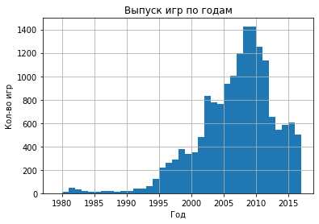

```python
set_label(data['year_of_release'].hist(bins=38, range=(1979, 2017)), labels=('Год', 'Кол-во игр'), title='Выпуск игр по годам')
```

Вывод по графику:

- На графике видно, что до 1995 выпускалось совсем мало игр
- Пик выпуска игр был с 2005 по 2012 (на глаз, дальше рассматриваю подробно каждый период)

## Комментарий ревьюера 🤔

Давай скорректируем количество корзин на графиках, чтобы убрать дыры. Для этого будет лучше всего рассчитать их как разницу между максимальным и минимальным значениями. И добавим вывод по этому графику)

## Комментарий ревьюера 😊 v_2

Отлично)

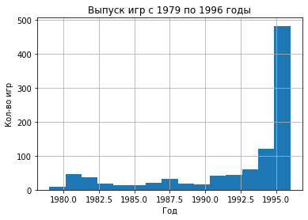

```python
set_label(data['year_of_release'].hist(bins=15, range=(1979, 1996)),
          labels=('Год', 'Кол-во игр'), title='Выпуск игр с 1979 по 1996 годы')
```

С 1980 по 1992 год выпущено самое малое кол-во игр, при необходимости эти данные можно отбросить

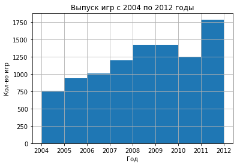

```python
set_label(data['year_of_release'].hist(bins=8, range=(2004, 2012)), labels=('Год', 'Кол-во игр'), title='Выпуск игр c 2004 по 2012 годы')
```

## Комментарий ревьюера 🤔 v_2

Здесь также необходимо скорректировать кол-во корзин на двух графиках.

## Комментарий ревьюера 😊 v_3

👍

Пик выпуска игр пришелся с 2005 по 2011 год

```python
# Посмотрите, как менялись продажи по платформам.
# Выберите платформы с наибольшими суммарными продажами и постройте распределение по годам.
# За какой характерный срок появляются новые и исчезают старые платформы?

platforms_canging = data.pivot_table(
    index='platform',
    values='sum_sales',
    aggfunc='sum'
).sort_values(
    by='sum_sales',
    ascending=False
)
```

```python
display(platforms_canging)
```

| platform | sum_sales |
| --- | --- |
| PS2 | 1233.56 |
| X360 | 961.24 |
| PS3 | 931.34 |
| Wii | 891.18 |
| DS | 802.78 |
| PS | 727.58 |
| PS4 | 314.14 |
| GBA | 312.88 |
| PSP | 289.53 |
| 3DS | 257.81 |
| PC | 255.76 |
| GB | 254.43 |
| XB | 251.57 |
| NES | 251.05 |
| N64 | 218.01 |
| SNES | 200.04 |
| GC | 196.73 |
| XOne | 159.32 |
| 2600 | 86.48 |
| WiiU | 82.19 |
| PSV | 53.81 |
| SAT | 33.59 |
| GEN | 28.35 |
| DC | 15.95 |
| SCD | 1.86 |
| NG | 1.44 |
| WS | 1.42 |
| TG16 | 0.16 |
| 3DO | 0.10 |
| GG | 0.04 |
| PCFX | 0.03 |

```python
platforms_top_10 = platforms_canging.iloc[0:10]
```

```python
platforms_top_10
```

| platform | sum_sales |
| --- | --- |
| PS2 | 1233.56 |
| X360 | 961.24 |
| PS3 | 931.34 |
| Wii | 891.18 |
| DS | 802.78 |
| PS | 727.58 |
| PS4 | 314.14 |
| GBA | 312.88 |
| PSP | 289.53 |
| 3DS | 257.81 |

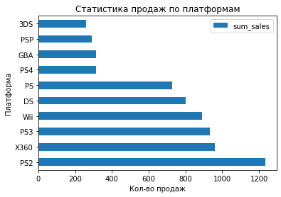

```python
set_label(platforms_top_10.plot.barh(), labels=('Кол-во продаж', 'Платформа'), title='Статистика продаж по платформам')
```

Вывод по графику:

На графике отображен топ 10 платформ по кол-ву продаж

Ранее эти данные были отображены в таблице, где подробно можно ознакомиься с продажами каждой платформы

Топ 3 здесь:

- ps2
- x360
- ps3

## Комментарий ревьюера 🤔

Так же следует добавить вывод по графику)

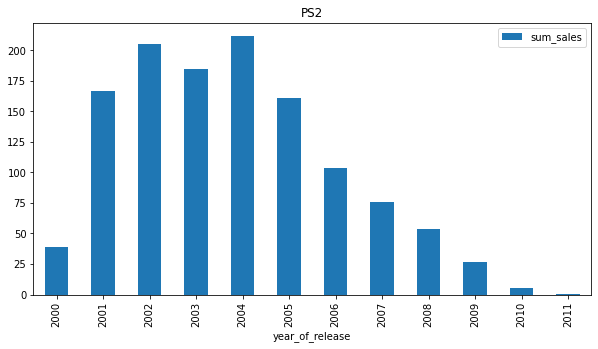

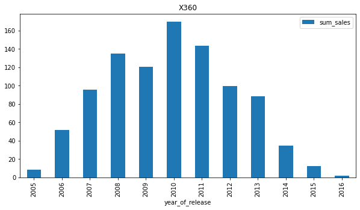

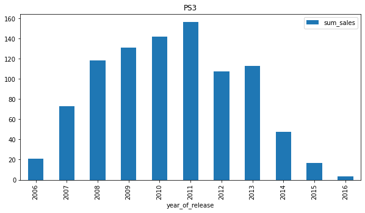

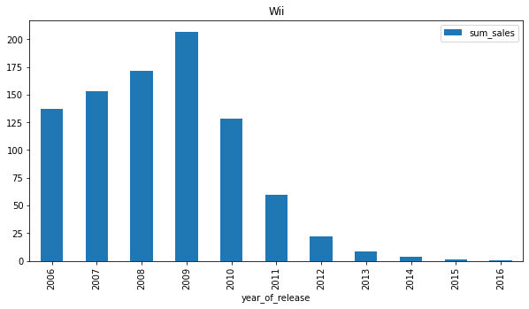

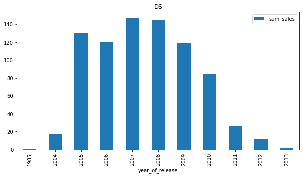

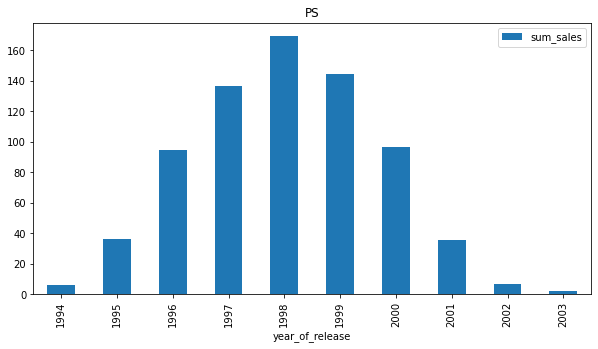

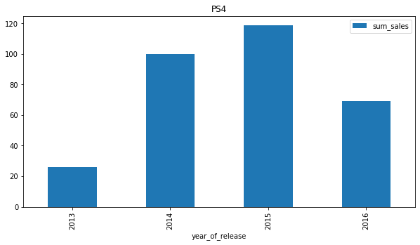

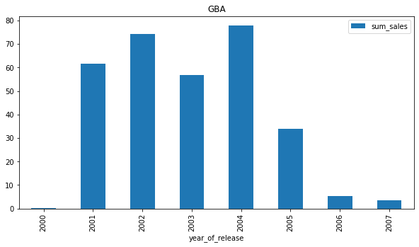

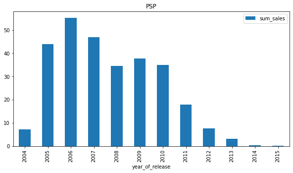

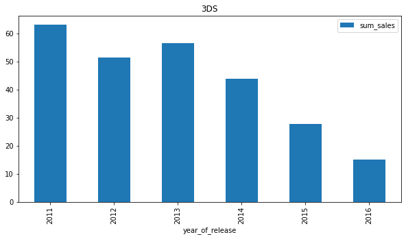

```python
# распределение по годам

for platform in platforms_top_10.index:
    filtered_data = data.loc[data['platform'] == platform]
    filtered_data.pivot_table(
        index='year_of_release',
        values='sum_sales',
        aggfunc='sum'
    ).plot(kind='bar', figsize=(10,5))
    plt.title(platform)
```

**Вывод:**

В среднем появляются новые платформы и исчезают старые раз в 5 лет. Получается, пятилетний цикл.

```python
# Возьмите данные за соответствующий актуальный период.

actual_data = data.query('year_of_release >= 2014')
```

## Комментарий ревьюера 🤔 v_2

На данном шаге очень важно выбрать актуальный период, причем как можно более ранний, поскольку резкий спад популярности платформы может произойти за 3-4 года. Если мы посмотрим на продажи игр по отдельности, как на графике ранее, мы можем увидеть, что лидером по продажам за всю историю PS2. Но продажи к 2011 году уже нулевые. X360 был на пике в 2010, но к 2016 упал почти до 0. Та же ситуация с PS3: к 2016 г. продажи стремятся к нулю, у Wii продажи нулевые уже в 2015 г. Соответственно, если мы выбираем более длинный период, мы рискуем захватить отстающий тренд, т.е. включаем в данные неактуальные платформы предпериода, которые не должны оставаться в данных для предсказываемом периоде. Outdated платформы лучше исключить из анализа, так как они будут искажать итоговые результаты, вносить устаревший тренд (к устаревшим платформам можно отнести X360, PS3, Wii, PSP)

**Комментарий студента:** получается, если я беру данные с 2016 года, отбрасывая при это все устаревшие платформы, я изучу совсем мало данных (в проекте же нужно простроить прогноз на 2017 год), это не исказит реальное положение вещей на рынке?

## Комментарий ревьюера 😊 v_3

Актуальный период выбран верно)

## Комментарий ревьюера 🤔 v_3

Верно, исказит. Поэтому следует использовать период в 2-3 года. Давай обновим работу в соотвествии с этим)

## Комментарий ревьюера 🤔

На данном шаге очень важно выбрать актуальный период, причем как можно более ранний, поскольку резкий спад популярности платформы может произойти за 3-4 года. Для целей прогнозирования продаж на следующий год даже в традиционных бизнесах редко берут данные более чем за 2-3 года. А в такой динамично меняющейся индустрии, как компьютерные игры и вовсе не стоит брать слишком большой временной интервал - иначе обязательно захватишь уже отжившие тренды. Но и слишком короткий период тоже брать не стоит.

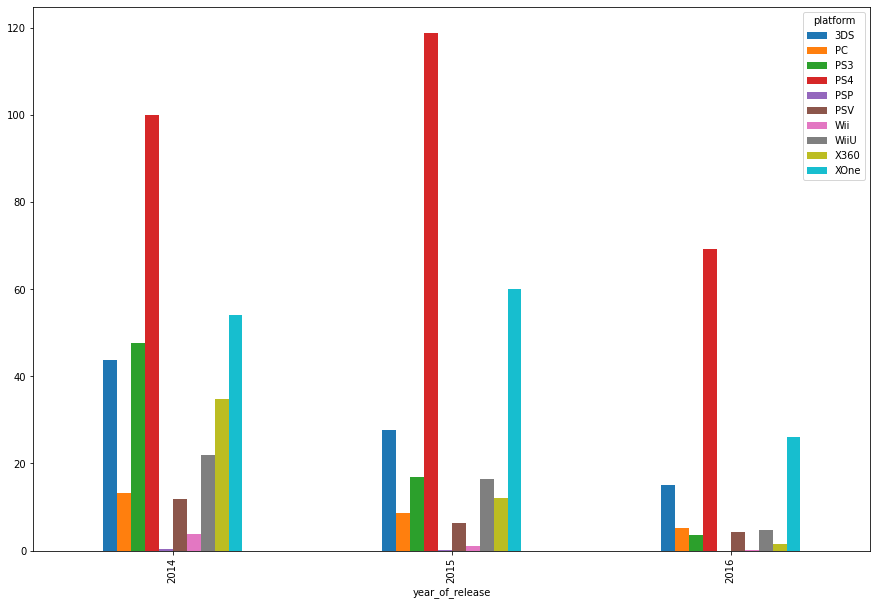

```python
# Какие платформы лидируют по продажам, растут или падают? Выберите несколько потенциально прибыльных платформ.

actual_data.pivot_table(
    index='year_of_release',
    columns = 'platform',
    values='sum_sales',
    aggfunc='sum'
).plot(kind='bar', figsize=(15, 10));
```

## Комментарий ревьюера 🤔

Сейчас мы фильтруем платформы из топ-10 с наиболее высокими продажами за весь период. А что если какая-нибудь из платформ только начала свой цикл и еще не успела по продажам войти в топ-10? Тогда получается, что мы выделим не все перспективные платформы на 2017 год? Давай доработаем и обновим вывод)

На диаграмме видно как постепенно падает ps3

- ps4 похоже на распределение пуассона, видно взлет в 2015 году, далее небольшой спад. Появилась эта платформа в 2013 году и беря во внимание цикл жизни платформ, в 2017 году ps4 еще будет пользоваться популярностью, но также будет идти на спад
- 3ds стабильно падает, но в 2017 году скорее всего еще будет продаваться
- довольно стабильно ведет себя XOne, начиная с 2013 года, видимо, тогда она только вышла. Скорее всего в 2017 году ее еще будут покупать и на нее будут делать игры.

Выберите несколько потенциально прибыльных платформ:

ps4 и XOne

## Комментарий ревьюера 😊 v_2

Да, согласна с твоими выводами, PS4 и XOne могут считаться потенциально прибыльными платформами для 2017 г.!

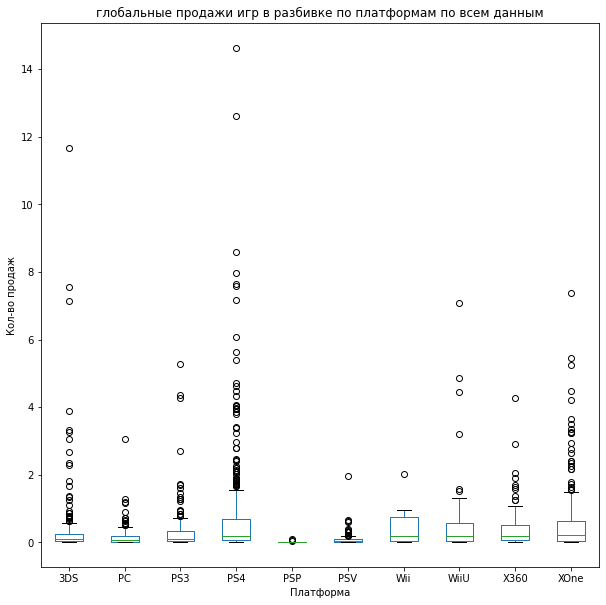

```python
# Постройте график «ящик с усами» по глобальным продажам игр в разбивке по платформам. Опишите результат.
# По полным данным

set_label(actual_data.pivot_table(index = 'name',
                        columns='platform',
                        values='sum_sales',
                        aggfunc='sum'
                       ).plot(kind='box',
                             figsize=(10,10)), labels=(
    'Платформа', 'Кол-во продаж'),
          title='глобальные продажи игр в разбивке по платформам по всем данным')
```

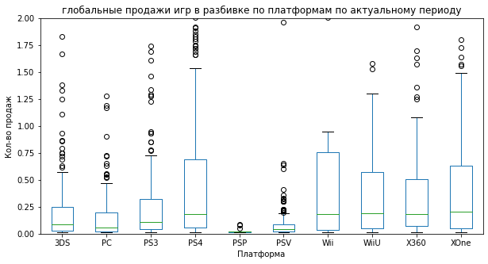

```python
# Постройте график «ящик с усами» по глобальным продажам игр в разбивке по платформам. Опишите результат.
# По актуальному периоду

set_label(actual_data.pivot_table(index = 'name',
                        columns='platform',
                        values='sum_sales',
                        aggfunc='sum'
                       ).plot(kind='box',
                              ylim=(0,2),
                             figsize=(10,5)), labels=('Платформа', 'Кол-во продаж'), title='глобальные продажи игр в разбивке по платформам по актуальному периоду')
```

**Вывод:**

выбросов много и все они над максимальным значением например, платформа pc все еще функционирует и продается, выбросы могут быть связаны с какими-то рекламными компаниями, выходом лимитированных версий игр, разбору авторитетного человека(больше про рекламу). Ошибки в данных также не исключаются.

## Комментарий ревьюера 🤔

После обновления актуального периода график измениться, не забудь обновить вывод) На нашем графике мы почти исключили выбросы по платформам, давай построим еще один график с полными данными, чтобы мы могли их отследить и также укажем возможные причины появления выбросов?)

## Комментарий ревьюера 🤔 v_2

График с полными данными - это график по актуальным данным, но без ограничения по оси У) Давай скорректируем)

## Комментарий ревьюера 😊 v_3

Теперь все отлично)

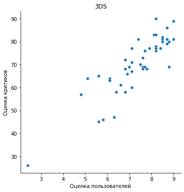

```python
# Посмотрите, как влияют на продажи внутри одной популярной платформы отзывы пользователей и критиков.
# Постройте диаграмму рассеяния и посчитайте корреляцию между отзывами и продажами. Сформулируйте выводы.

DS = actual_data.query('platform == "3DS"')

graph = sns.relplot(data=DS, x='user_score', y='critic_score', kind='scatter');
set_label(graph.axes.flat[0], ('Оценка пользователей', 'Оценка критиков'), '3DS')
```

На графике видна прямая корреляция между оценками критиков и пользователей

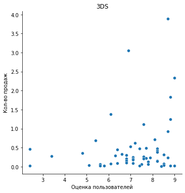

```python
graph = sns.relplot(data=DS, x='user_score', y='sum_sales', kind='scatter');
set_label(graph.axes.flat[0], ('Оценка пользователей', 'Кол-во продаж'), '3DS')
```

как мы видим, пользователи не особо влияют на продажи

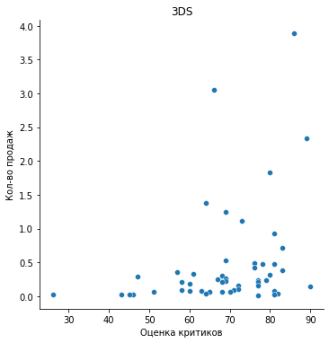

```python
graph = sns.relplot(data=DS, x='critic_score', y='sum_sales', kind='scatter');
set_label(graph.axes.flat[0], ('Оценка критиков', 'Кол-во продаж'), '3DS')
```

и критики тоже в большинстве случаев. Есть выбросы. Возможно они связаны с какой-то конкретной игрой, а возможно просто ошибка в д-х. Тоже самое могу сказать в случае оценки пользователей

```python
PS3_cor = DS[['critic_score','user_score', 'sum_sales']]
PS3_cor.corr()
```

|  | critic_score | user_score | sum_sales |
| --- | --- | --- | --- |
| critic_score | 1.000000 | 0.862485 | 0.314117 |
| user_score | 0.862485 | 1.000000 | 0.215193 |
| sum_sales | 0.314117 | 0.215193 | 1.000000 |

## Комментарий ревьюера 😊

Коэффициенты корреляции расчитаны верно, молодец)

**Вывод:**

Прослеживается прямая корреляция между отзывами критиков и пользователей. Также видно, что оценки критиков и пользователей на продажи практически не влияют.

## Комментарий ревьюера 🤔

В данном пункте нам необходимо изучить влияние оценок пользователей на продажи и также влияние оценок критиков на продажи. Т.е. построить два графика, вместо одного) Давай скорректируем визуаизацию по данному пункту)

## Комментарий ревьюера 😊 v_2

Верно)

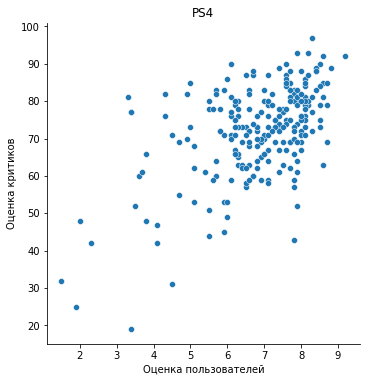

```python
# Соотнесите выводы с продажами игр на других платформах

PS4 = actual_data.query('platform == "PS4"')
graph = sns.relplot(data=PS4, x='user_score', y='critic_score', kind='scatter');
set_label(graph.axes.flat[0], ('Оценка пользователей', 'Оценка критиков'), 'PS4')
```

Также прямая связь между оценками

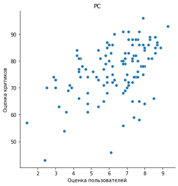

```python
PC = actual_data.query('platform == "PC"')
graph = sns.relplot(data=PC, x='user_score', y='critic_score', kind='scatter');
set_label(graph.axes.flat[0], ('Оценка пользователей', 'Оценка критиков'), 'PC')
```

слабая прямая корреляция между оценками

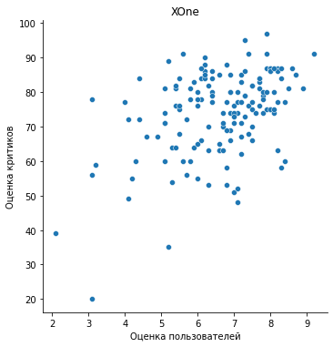

```python
XOne = actual_data.query('platform == "XOne"')
graph = sns.relplot(data=XOne, x='user_score', y='critic_score', kind='scatter');
set_label(graph.axes.flat[0], ('Оценка пользователей', 'Оценка критиков'), 'XOne')
```

Также прямая связь между оценками

```python
PS4_cor = PS4[['critic_score','user_score', 'sum_sales']]
PS4_cor.corr()
```

|  | critic_score | user_score | sum_sales |
| --- | --- | --- | --- |
| critic_score | 1.000000 | 0.546434 | 0.402661 |
| user_score | 0.546434 | 1.000000 | -0.040132 |
| sum_sales | 0.402661 | -0.040132 | 1.000000 |

```python
PC_cor = PC[['critic_score','user_score', 'sum_sales']]
PC_cor.corr()
```

|  | critic_score | user_score | sum_sales |
| --- | --- | --- | --- |
| critic_score | 1.000000 | 0.466099 | 0.174634 |
| user_score | 0.466099 | 1.000000 | -0.071597 |
| sum_sales | 0.174634 | -0.071597 | 1.000000 |

```python
XOne_cor = XOne[['critic_score','user_score', 'sum_sales']]
XOne_cor.corr()
```

|  | critic_score | user_score | sum_sales |
| --- | --- | --- | --- |
| critic_score | 1.000000 | 0.440977 | 0.428677 |
| user_score | 0.440977 | 1.000000 | -0.070384 |
| sum_sales | 0.428677 | -0.070384 | 1.000000 |

**Вывод об PS4, XOne и pc:**

Прямая связь между отзывами критиков и пользователей. Также видно, что оценки критиков влияют на продажи, а оценки пользователей не берут во внимание. отрицательная корреляция между продажами и оценкой пользователей, но цифра слишком маленькая, так что связи нет.

## Комментарий ревьюера 😊

Верно)

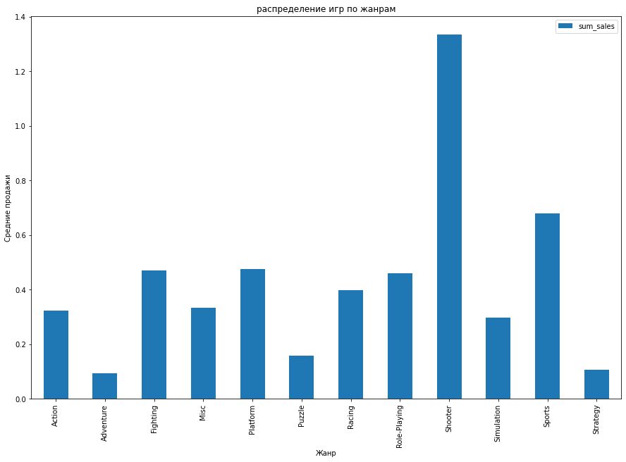

```python
# Посмотрите на общее распределение игр по жанрам.
# Что можно сказать о самых прибыльных жанрах? Выделяются ли жанры с высокими и низкими продажами?

set_label(actual_data.pivot_table(
    index='genre',
    values='sum_sales',
).plot(kind='bar', figsize=(15, 10)), labels=('Жанр', 'Средние продажи'), title='распределение игр по жанрам')
```

## Комментарий ревьюера 🤔

Общие продажи - плохая метрика для поиска наиболее прибыльного жанра. За высокими показателями общих продаж может скрываться множество мелких игр с низкими продажами. Или 2-3 звезды и куча провалов. Лучше найти жанр, где игры стабильно приносят высокий доход - для этого стоит рассмотреть средние или медианные продажи. В данном случае более подходящей будет график столбчатой диаграммы)

## Комментарий ревьюера 😊 v_2

Отлично)

**Вывод:**

- Самые прибыльные жанры shooter, sports, platform, fighting
- Самые низкие продажи у strategy и adventure

## Комментарий ревьюера 😊

Хорошая работа по исследовательскому анализу, но кое-что нуждается в доработке)

## Шаг 4. Составьте портрет пользователя каждого региона

Определите для пользователя каждого региона (NA, EU, JP):

- Самые популярные платформы (топ-5). Опишите различия в долях продаж.
- Самые популярные жанры (топ-5). Поясните разницу.
- Влияет ли рейтинг ESRB на продажи в отдельном регионе?

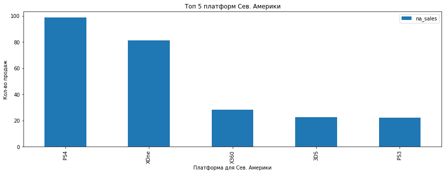

```python
# Самые популярные платформы (топ-5).

na_sales = actual_data.pivot_table(
    index='platform',
    values='na_sales',
    aggfunc='sum').sort_values(
    ascending=False,
    by='na_sales')

set_label(na_sales.head(5).plot(
    kind='bar',
    figsize=(15,5)), labels=('Платформа для Сев. Америки', 'Кол-во продаж'), title='Топ 5 платформ Сев. Америки')
```

```python
# Опишите различия в долях продаж.

na_sales['part'] = (na_sales['na_sales'] / na_sales['na_sales'].sum()) * 100

na_sales.head(5)
```

| platform | na_sales | part |
| --- | --- | --- |
| PS4 | 98.61 | 34.714497 |
| XOne | 81.27 | 28.610153 |
| X360 | 28.30 | 9.962684 |
| 3DS | 22.64 | 7.970147 |
| PS3 | 22.05 | 7.762445 |

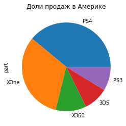

```python
na_sales['part'].head(5).plot(kind='pie', title='Доли продаж в Америке');
```

В северной Америке пользуются популярностью ps4(34%), xOne(28%), x360(9%), 3ds(7%), ps3(7%)

## Комментарий ревьюера 🤔 v_3

Давай обновим выводы в соответствии с графиками)

## Комментарий ревьюера 🤔

После обновления актуального периода, лидеры по регионам изменятся. Давай оставим на графике только интересующую нас пятерку лидеров. Для этого перед построением можно добавить .head().

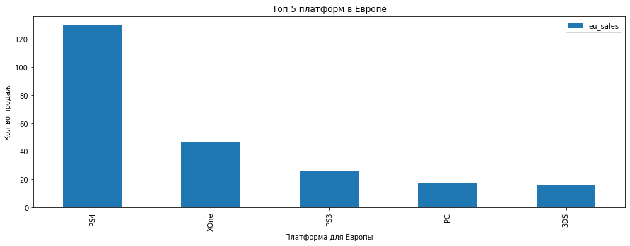

```python
eu_sales = actual_data.pivot_table(
    index='platform',
    values='eu_sales',
    aggfunc='sum').sort_values(
    ascending=False,
    by='eu_sales')

set_label(eu_sales.head(5).plot(
    kind='bar',
    figsize=(15,5)), labels=('Платформа для Европы', 'Кол-во продаж'), title='Топ 5 платформ в Европе')
```

```python
eu_sales['part'] = (eu_sales['eu_sales'] / eu_sales['eu_sales'].sum()) * 100

eu_sales.head(5)
```

| platform | eu_sales | part |
| --- | --- | --- |
| PS4 | 130.04 | 48.041968 |
| XOne | 46.25 | 17.086597 |
| PS3 | 25.54 | 9.435496 |
| PC | 17.97 | 6.638836 |
| 3DS | 16.12 | 5.955372 |

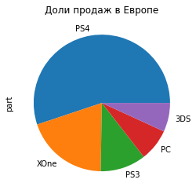

```python
eu_sales['part'].head(5).plot(kind='pie', title='Доли продаж в Европе');
```

В Европе пользуются популярностью ps4(48%), xOne(17%), ps3(9%), pc(6%), 3ds(5%)

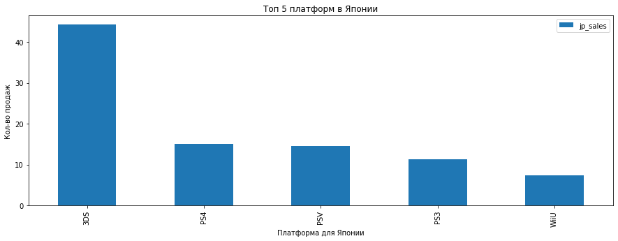

```python
jp_sales = actual_data.pivot_table(
    index='platform',
    values='jp_sales',
    aggfunc='sum').sort_values(
    ascending=False,
    by='jp_sales')

set_label(jp_sales.head(5).plot(
    kind='bar',
    figsize=(15,5)), labels=('Платформа для Японии', 'Кол-во продаж'), title='Топ 5 платформ в Японии')
```

```python
jp_sales['part'] = (jp_sales['jp_sales'] / jp_sales['jp_sales'].sum()) * 100

jp_sales.head(5)
```

| platform | jp_sales | part |
| --- | --- | --- |
| 3DS | 44.24 | 47.523902 |
| PS4 | 15.02 | 16.134923 |
| PSV | 14.54 | 15.619293 |
| PS3 | 11.22 | 12.052852 |
| WiiU | 7.31 | 7.852616 |

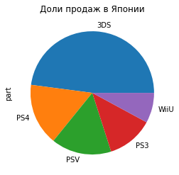

```python
jp_sales['part'].head(5).plot(kind='pie', title='Доли продаж в Японии');
```

В Японии пользуются популярностью 3ds(47%), ps4(16%), psv(15%), ps3(12%), wiiu(7%)

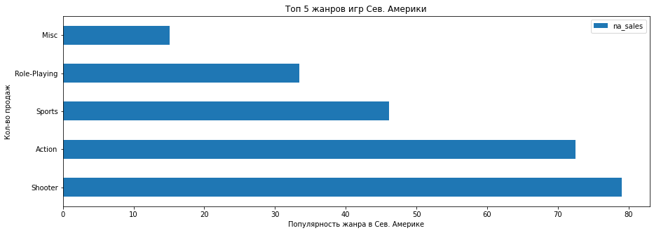

```python
# Самые популярные жанры (топ-5). Поясните разницу.

set_label(actual_data.pivot_table(
    index='genre',
    values='na_sales',
    aggfunc='sum').sort_values(
    by='na_sales', ascending=False).head(5).plot(
    kind='barh',
    figsize=(15,5)), labels=('Популярность жанра в Сев. Америке', 'Кол-во продаж'), title='Топ 5 жанров игр Сев. Америки')
```

## Комментарий ревьюера 🤔 v_2

Сейчас мы выводим последние 5 жанров по по продажам, давай скорректируем фильтрацию здесь и далее)

Самые популярные жанры в Америке shooter, action, sports, role-playing, misc

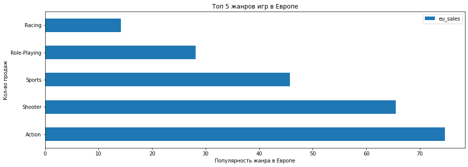

```python
set_label(actual_data.pivot_table(
    index='genre',
    values='eu_sales',
    aggfunc='sum').sort_values(
    by='eu_sales', ascending=False).head(5).plot(
    kind='barh',
    figsize=(15,5)), labels=('Популярность жанра в Европе', 'Кол-во продаж'), title='Топ 5 жанров игр в Европе')
```

Самые популярные жанры в Европе action, shooter, sports, role-playing, racing

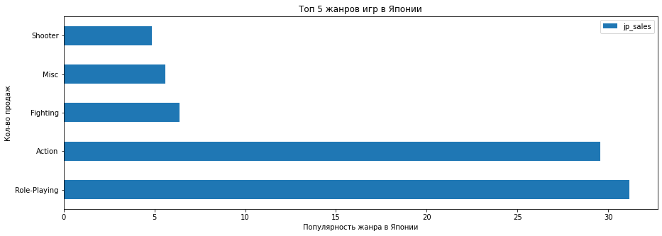

```python
set_label(actual_data.pivot_table(
    index='genre',
    values='jp_sales',
    aggfunc='sum').sort_values(
    by='jp_sales', ascending=False).head(5).plot(
    kind='barh',
    figsize=(15,5)), labels=('Популярность жанра в Японии', 'Кол-во продаж'), title='Топ 5 жанров игр в Японии')
```

Самые популярные жанры в Японии role-plaing, action, fighting, misc, shooter

## Комментарий ревьюера 😊

Здорово, что ты использовала barh для построения, отлично подходит для графиков с длинными подписями)

## Комментарий ревьюера 🤔

Давай также оставим топ-5 по жанрам в каждом регионе)

```python
# Влияет ли рейтинг ESRB на продажи в отдельном регионе?

ESRB = actual_data.pivot_table(index='rating', values=['eu_sales','jp_sales','na_sales'])
ESRB
```

| rating | eu_sales | jp_sales | na_sales |
| --- | --- | --- | --- |
| 0 | 0.078705 | 0.075968 | 0.086409 |
| E | 0.265114 | 0.040822 | 0.231689 |
| E10+ | 0.141405 | 0.024108 | 0.179622 |
| M | 0.352604 | 0.030226 | 0.363849 |
| T | 0.125720 | 0.054539 | 0.143727 |

да, влияет. Например,

- в японии на первом месте игры без рейтинга, далее идет T, E, M, E10+
- В Европе М, E, Е10+, Т, игры без рейтинга
- В США М, Е, Е10+, Т, игры без рейтинга

Расшифровки:

- «E» («Everyone») — «Для всех»
- «E10+» («Everyone 10 and older») — «Для всех от 10 лет и старше»
- «T» («Teen») — «Подросткам»
- «M» («Mature») — «Для взрослых»

## Комментарий ревьюера 🤔

При нашем способе подсчета игры без рейтинга оказываются полностью исключенными из анализа. Но продажи именно этих игр могут указать на ключевое различие в регионах. Давай добавим их в анализ. В вывод также можно указать расшифровки рейтингов)

## Комментарий ревьюера 😊 v_2

👍

**Комментарий студента:** мне же по актуальному периоду смотреть рейтинг?)

## Комментарий ревьюера 😊 v_3

Да

## Комментарий ревьюера 😊

Молодец, что добавила визуализацию в данном блоке)

## Шаг 5. Проверьте гипотезы

- Средние пользовательские рейтинги платформ Xbox One и PC одинаковые;
- Средние пользовательские рейтинги жанров Action (англ. «действие», экшен-игры) и Sports (англ. «спортивные соревнования») разные.

Задайте самостоятельно пороговое значение alpha.

Поясните:

- Как вы сформулировали нулевую и альтернативную гипотезы;
- Какой критерий применили для проверки гипотез и почему.

```python
# Средние пользовательские рейтинги платформ Xbox One и PC одинаковые;
```

H0: Средний пользовательский рейтинг платформы Xbox One = PC

H1: Средний пользовательский рейтинг платформы Xbox One ≠ PC

## Комментарий ревьюера 😊

Гипотезы составлены верно)

```python
XOne = actual_data[(actual_data['platform'] == 'XOne') &  (actual_data['user_score'] > 0)]['user_score']
PC = actual_data[(actual_data['platform'] == 'PC') &  (actual_data['user_score'] > 0)]['user_score']

alpha = .05

results = st.ttest_ind(XOne, PC, equal_var=False)

print('p-значение:', results.pvalue)


if (results.pvalue < alpha):
    print("Отвергаем нулевую гипотезу")
else:
    print("Не получилось отвергнуть нулевую гипотезу")
```

```
p-значение: 0.11601398086668832
Не получилось отвергнуть нулевую гипотезу
```

```python
# check

XOne = actual_data[(actual_data['platform'] == 'XOne') &  (actual_data['user_score'] > 0)]['user_score'].mean()
PC = actual_data[(actual_data['platform'] == 'PC') &  (actual_data['user_score'] > 0)]['user_score'].mean()

print(XOne)
print(PC)
```

```
6.594545454545456
6.298360655737705
```

Не получилось отвергнуть нулевую гипотезу, а значит высокая вероятность, что средние пользовательские рейтинги платформ Xbox One и PC одинаковые

## Комментарий ревьюера 🤔

После обновления актуального периода мы получим новые результаты, не забудь обновить выводы)

## Комментарий ревьюера 😊 v_2

Сейчас все верно)

```python
# Средние пользовательские рейтинги жанров Action (англ. «действие», экшен-игры)
# и Sports (англ. «спортивные соревнования») разные.
```

H0: Средний пользовательский рейтинг жанра Action = Sports

H1: Средний пользовательский рейтинг жанра Action ≠ Sports

## Комментарий ревьюера 😊 v_2

Правильно)

## Комментарий ревьюера 🤔

Гипотезы сформулированы не верно, давай скорректируем. Предполагается, что действительное различие сравниваемых величин равно нулю (в нулевой гипотезе), а выявленное по данным отличие от нуля носит случайный характер. Об этом можно подробнее почитать в статьях: http://www.mathprofi.ru/statisticheskie_gipotezy.html http://statistica.ru/theory/proverka-gipotez/

```python
Action = actual_data[(actual_data['genre'] == 'Action') &  (actual_data['user_score'] > 0)]['user_score']
Sports = actual_data[(actual_data['genre'] == 'Sports') &  (actual_data['user_score'] > 0)]['user_score']

alpha = .05

results = st.ttest_ind(Action, Sports, equal_var=False)

print('p-значение:', results.pvalue)


if (results.pvalue < alpha):
    print("Отвергаем нулевую гипотезу")
else:
    print("Не получилось отвергнуть нулевую гипотезу")
```

```
p-значение: 1.1825550382644557e-14
Отвергаем нулевую гипотезу
```

```python
# check

Action = actual_data[(actual_data['genre'] == 'Action') &  (actual_data['user_score'] > 0)]['user_score'].mean()
Sports = actual_data[(actual_data['genre'] == 'Sports') &  (actual_data['user_score'] > 0)]['user_score'].mean()
print(Action)
print(Sports)
```

```
6.760606060606061
5.2251968503937
```

Получается, средние пользовательские рейтинги жанров Action и Sports различаются

## Комментарий ревьюера 😊

Здорово, что ты выводишь средние показатели и профодишь фильтрацию пропусков перед расчетами. Осталось обновить результаты после изменения актуаьного периода и скорректировать гипотезы)

## Шаг 6. Напишите общий вывод

**Общий вывод:**

**Портрет пользователей:**

Европа

- В Европе пользуются популярностью ps4(48%), xOne(17%), ps3(9%), pc(6%), 3ds(5%). Самые популярные жанры action, shooter, sports, role-playing, racing
- Рейтинг влияет на продажи, вот топ рейтинга по средним продажам М, E, Е10+, Т, игры без рейтинга

Япония

- В Японии пользуются популярностью 3ds(47%), ps4(16%), psv(15%), ps3(12%), wiiu(7%). Самые популярные жанры role-plaing, action, fighting, misc, shooter
- Рейтинг влияет на продажи,на первом месте игры без рейтинга, далее идет T, E, M, E10+

**Прогноз на 2017 год:**

- Потенциально прибыльные платформы: ps4 и XOne
- Потенциально прибыльные жанры shooter, sports, platform, fighting

## Комментарий ревьюера 🤓

Мы не можем утверждать, что средние пользовательские рейтинги платформ Xbox One и PC одинаковые, так как мы проверили гипотезы на основе ВЫБОРОК. Поскольку нулевая гипотеза выдвигается на основе анализа ВЫБОРОЧНЫХ данных, то она может оказаться как правильной, так и неправильной. Более того, мы не сможем на 100% гарантировать её истинность либо ложность даже после статистической проверки! Ибо любая, самая «надёжная» выборка все равно остаётся выборкой и может нас дезинформировать (пусть с очень малой вероятностью). Т.е. мы смогли бы так утверждать, если бы проверили всевозможные рейтинги всех игр на этих платформах. Но т.к. мы проверяли лишь небольшую выборку, у нас лишь есть основания полагать, что эти выборки равны. Корректнее написать о том, что у нас нет/есть оснований утверждать, что средние пользовательские рейтинги платформ Xbox One и PC значимо различаются. Такие выводы очень важная часть статистических анализов. Поэтому давай исправим) Если будет интересно, то вот пара ссылок на доп. материалы по статистике: http://www.mathprofi.ru/statisticheskie_gipotezy.html https://allatambov.github.io/psms/pdf/hypo-test.pdf

## Комментарий ревьюера 🤔

Общий вывод это главный итог твоей работы. Будет здорово добавить портреты пользователей, а также обновить данные в соответствии с проектом и рекоендации безнесу по прогнозу на 2017 год.

## Комментарий ревьюера 😊 v_2

Замечательный вывод по работе)

## Общий комментарий ревьюера 😊 v_4

Наталья, cпасибо за проект! Успехов в дальнейшем обучении!)

## Общий комментарий ревьюера 😊 v_3

Наталья, осталось обновить актуальный период и выводы в соответствии с работой)

## Общий комментарий ревьюера 😊 v_2

Наталья, ты отлично поработала, но кое-что еще нужно доработать, необходимо скорректировать временные границы, обновить портреты по регионам, остальные комментарии ты найдешь в работе)

## Общий комментарий ревьюера 😊

Наталья, ты проделала хорошую работу, основные задачи проекта решены. Однако, есть несколько важных моментов, которые стоит улучшить, чтобы проект стал действительно идеальным! Необходимо доработать: * Переопределить временные границы. * Обработка пропусков. * Стоит добавить анализ игр без рейтинга, для этого обрати еще раз внимание на стратегию обработки пропусков в этой колонке. * Актуализировать результаты и выводы. * Подобнее рассмотреть распределение игр по жанрам * Скорректировать визуализацию * Остальные комментарии ты найдешь в работе **Желаю удачи и жду твой проект на повторное ревью! Если у тебя вдруг есть какие–либо вопросы, то я с радостью отвечу на них 😊** ![gif](https://i.gifer.com/378.gif) Также оставлю дополнительный материал по визуализации, если будет интересно: * книга Александра Богачева [Графики, которые убеждают всех](https://book24.ru/product/grafiki-kotorye-ubezhdayut-vsekh-5873820/) * [cheatsheet по визуализации](https://extremepresentation.typepad.com/.a/6a00d8341bfd2e53ef0111683a7591970c-pi) * бесплатный курс от Яндекс.Практикум [Визуальныe презентации](https://practicum.yandex.ru/visual-presentation/) * Формат таблиц в pandas с помощью style. В том числе цветовое выделение. (https://habr.com/ru/post/521894/) * Основные компоненты matplotlib (https://pyprog.pro/mpl/mpl_main_components.html) * 50 оттенков matplotlib — The Master Plots (с полным кодом на Python) (https://habr.com/ru/post/468295/) * Построение графиков с использованием двух осей. (https://matplotlib.org/stable/gallery/subplots_axes_and_figures/two_scales.html) * Сайт, подробно представлюящий практически все типы визуализаций. (https://datavizproject.com/) * Шпаргалка по визуализации данных в Python с помощью Plotly (https://habr.com/ru/post/502958/)